# Projet Analyse de données : Meteorite Landings

Jonathan Ferreira

## Carte du monde avec météorites.

On commence par récuperer le jeu de données dans une variable qu’on nommera `didou`.

```r
didou <- read_csv(
    "Meteorite.csv")

print(didou, width = Inf)
```

```
## # A tibble: 45,716 x 10
##    name                   id nametype recclass    `mass (g)` fall
##    <chr>               <dbl> <chr>    <chr>            <dbl> <chr>
##  1 Aachen                  1 Valid    L5                  21 Fell
##  2 Aarhus                  2 Valid    H6                 720 Fell
##  3 Abee                    6 Valid    EH4             107000 Fell
##  4 Acapulco               10 Valid    Acapulcoite       1914 Fell
##  5 Achiras               370 Valid    L6                 780 Fell
##  6 Adhi Kot              379 Valid    EH4               4239 Fell
##  7 Adzhi-Bogdo (stone)   390 Valid    LL3-6              910 Fell
##  8 Agen                  392 Valid    H5               30000 Fell
##  9 Aguada                398 Valid    L6                1620 Fell
## 10 Aguila Blanca         417 Valid    L                 1440 Fell
##    year                   reclat  reclong GeoLocation
##    <chr>                   <dbl>    <dbl> <chr>
##  1 01/01/1880 12:00:00 AM   50.8    6.08  (50.775, 6.08333)
##  2 01/01/1951 12:00:00 AM   56.2   10.2   (56.18333, 10.23333)
##  3 01/01/1952 12:00:00 AM   54.2 -113     (54.21667, -113.0)
##  4 01/01/1976 12:00:00 AM   16.9  -99.9   (16.88333, -99.9)
##  5 01/01/1902 12:00:00 AM  -33.2  -65.0   (-33.16667, -64.95)
##  6 01/01/1919 12:00:00 AM   32.1   71.8   (32.1, 71.8)
##  7 01/01/1949 12:00:00 AM   44.8   95.2   (44.83333, 95.16667)
##  8 01/01/1814 12:00:00 AM   44.2    0.617 (44.21667, 0.61667)
##  9 01/01/1930 12:00:00 AM  -31.6  -65.2   (-31.6, -65.23333)
## 10 01/01/1920 12:00:00 AM  -30.9  -64.6   (-30.86667, -64.55)
## # ... with 45,706 more rows
```

On cherche les valeurs absurdes dans les colonnes `reclat` et `reclong` représentants les coordonnées en lattitude et longitude, et on les remplace par des `NA`.

```r
didou <- didou %>%
  mutate(reclat = ifelse(reclat > 90 | reclat < -90, NA, reclat)) %>%
  mutate(reclong = ifelse(reclong > 180 | reclong < -180, NA, reclong))
```

On vérifie qu’à chaque fois que la colonne `reclat` et la colonne `reclong` sont égales à `0`, la colonne `GeoLocalisation` est bien égale à `(0.0, 0.0)`.

```r
#Ici on vérifie l'inverse
didou %>%
  filter(reclat == 0 & reclong == 0 & GeoLocation != "(0.0, 0.0)") %>%
  nrow()
```

```
## [1] 0
```

On cherche maintenant à savoir combien de météorites sont répertoriées aux coordonnées `(0.0, 0.0)`.

```r
nbrzero <- didou %>%
  filter(GeoLocation == "(0.0, 0.0)") %>%
  nrow()
```

On remarque que 6214 météorites sont répertoriées en `(0.0, 0.0)`. On cherche à vérifier si c’est la véritable coordonnées des météorites, sinon on remplacera par des `NA`.  
Le nom des météorites est défini par un lieu de découverte et un nombre s’il y a plusieurs météorites associées à un même lieu, grâce à la fonction `unique` et en ignorant les numéros, on peut donc faire ressortir les lieux où ces météorites ont été découvertes.

```r
#didou <- didou %>%
#  filter(reclat == 0 & reclong == 0) %>%
#  summarize(where = unique(sub("[0-9]+", "", name))) %>%
#  unique()

#OU

didou %>%
  filter(GeoLocation == "(0.0, 0.0)") %>%
  summarize(where = str_replace_all(name, "[:digit:]", "")) %>%
  unique()
```

```
## # A tibble: 18 x 1
##    where
##    <chr>
##  1 "Northwest Africa "
##  2 "Mason Gully"
##  3 "Allan Hills "
##  4 "Buckley Island "
##  5 "Dominion Range "
##  6 "Graves Nunataks "
##  7 "LaPaz Icefield "
##  8 "Larkman Nunatak "
##  9 "Miller Range "
## 10 "Mount Howe "
## 11 "New York"
## 12 "Nova "
## 13 "Patuxent Range "
## 14 "Sahara "
## 15 "Scott Glacier "
## 16 "Shawnee"
## 17 "Uasara"
## 18 "Yamato "
```

On voit que ces lieux ne sont pas en (0.0, 0.0), donc on peut bien les remplacer par des `NA`.

```r
didou <- didou %>%
  mutate(reclat = ifelse(GeoLocation == "(0.0, 0.0)", NA, reclat)) %>%
  mutate(reclong = ifelse(GeoLocation == "(0.0, 0.0)", NA, reclong)) %>%
  mutate(GeoLocation = ifelse(GeoLocation == "(0.0, 0.0)", NA, GeoLocation))
```

On cherche maintenant à faire une représentation graphiques à partir des données récupérées.

On importe une carte du monde afin d’y positionner les météorites.

```r
worldmap <- ggplot() +
  geom_polygon(data = map_data("world"),
               mapping = aes(long, lat, group = group),
               fill = "white", colour = "grey") +
  xlab("Longitude") + ylab("Lattitude")
```

On marque les positions des météorites à l’aide d’un `geom_point`.

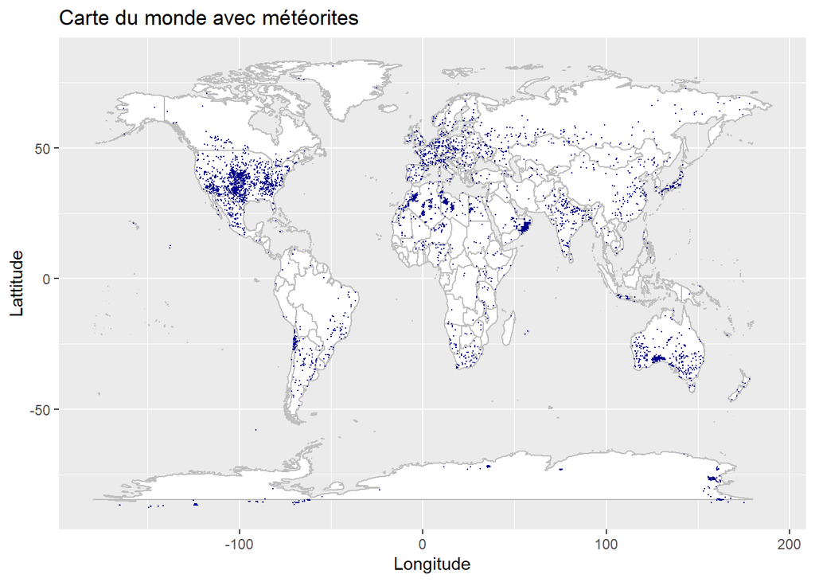

```r
worldmap +
  geom_point(data = didou, mapping = aes(x = reclong, y = reclat), colour = 'darkblue', size = 0.1) +
  labs(title = "Carte du monde avec météorites")
```

## Animation d’une carte du monde avec lieu d’impact des météorites dans le temps.

On va maintenant faire une animation dans le temps, des météorites dont on connait la date d’impact.

On remarque d’abord que le nom de colonne `mass (g)` posera problème, on renomme donc la colonne en `mass` et on rapellera l’unité dans les graphiques. Puis, on formate la colonne `year`, car le jour/mois et l’heure n’ont ici aucune valeur (toujours la même : 1er Janvier à 12AM, sauf erreur (ou cas spécifique ?)), On vérifiera aussi qu’il n’y a pas de valeurs absurdes (année plus grande que l’année en cours).

```r
colnames(didou)[5] <- "mass"

#On veut voir quels météorites n'ont pas été enregistré au 1er Janvier à 12AM
didou %>%
  filter(!str_detect(year, "01/01.+12:00:00 AM"))
```

```
## # A tibble: 9 x 10
##   name      id nametype recclass    mass fall  year  reclat  reclong GeoLocation
##   <chr>  <dbl> <chr>    <chr>      <dbl> <chr> <chr>  <dbl>    <dbl> <chr>
## 1 Elbog~  7823 Valid    Iron, I~  1.07e5 Fell  12/2~   50.2  12.7    (50.18333,~
## 2 Ensis~ 10039 Valid    LL6       1.27e5 Fell  12/2~   47.9   7.35   (47.86667,~
## 3 Narni  16914 Valid    Stone-u~ NA      Fell  12/2~   42.5  12.5    (42.51667,~
## 4 Nogata 16988 Valid    L6        4.72e2 Fell  12/2~   33.7 131.     (33.725, 1~
## 5 Oliva~ 18012 Valid    Stone-u~ NA      Fell  12/2~   39    -0.0333 (39.0, -0.~
## 6 Rivol~ 22614 Valid    Stone-u~  1.03e2 Fell  12/2~   45.5   9.52   (45.48333,~
## 7 Valdi~ 24146 Valid    Stone-u~ NA      Fell  12/2~   44.1  12.1    (44.06667,~
## 8 Campo~  5247 Valid    Iron, I~  5   e7 Found 12/2~  -27.5 -60.6    (-27.46667~
## 9 North~ 32870 Valid    CV3       1.68e2 Found 01/0~   NA    NA      <NA>
```

```r
didou <- didou %>%
  mutate(year = as.integer((year(mdy_hms(didou$year))))) %>%
  mutate(year = ifelse(year > as.numeric(format(Sys.Date(), "%Y")), NA, year))
```

On utilisera le poids `mass` de la météorite comme taille du point. On choisi aussi d’utiliser la composition de la météorite comme code couleur, il en existe 3 types : `Stony` `Irony` `Stony-Iron`. Dans la colonne `recclass`, uniquement le sous-type est donné, il en existe beaucoup trop pour que le graphique soit clair, on utilisera donc la fonction `mutate` pour créer une nouvelle colonne qui contient le type principal associé à chaque météorite.

```r
didou <- didou %>%
  mutate(colorclass = ifelse(grepl("Stone|CI|CM|CO|CV|CK|CR|CH|CB|H|L|LL|EH|EL|R|K|URE|BRA|ACA|LOD|WIN|ANG|AUB|EUC|DIO|HOW|MOON|SHE|NAK|CHA|OPX|Diogenite|Eucrite", recclass), "Stony", NA)) %>%
  mutate(colorclass = ifelse(grepl("Iron|IAB|IIICD|IC|IIAB|IIC|IID|IIE|IIIAB|IIIE|IIIF|IVA|IVB", recclass), "Irony", colorclass)) %>%
  mutate(colorclass = ifelse(grepl("Pallasite|MES|ES|PAL|PP", recclass), "Stony-Iron", colorclass))

print(didou, width = Inf)
```

```
## # A tibble: 45,716 x 11
##    name                   id nametype recclass      mass fall   year reclat
##    <chr>               <dbl> <chr>    <chr>        <dbl> <chr> <int>  <dbl>
##  1 Aachen                  1 Valid    L5              21 Fell   1880   50.8
##  2 Aarhus                  2 Valid    H6             720 Fell   1951   56.2
##  3 Abee                    6 Valid    EH4         107000 Fell   1952   54.2
##  4 Acapulco               10 Valid    Acapulcoite   1914 Fell   1976   16.9
##  5 Achiras               370 Valid    L6             780 Fell   1902  -33.2
##  6 Adhi Kot              379 Valid    EH4           4239 Fell   1919   32.1
##  7 Adzhi-Bogdo (stone)   390 Valid    LL3-6          910 Fell   1949   44.8
##  8 Agen                  392 Valid    H5           30000 Fell   1814   44.2
##  9 Aguada                398 Valid    L6            1620 Fell   1930  -31.6
## 10 Aguila Blanca         417 Valid    L             1440 Fell   1920  -30.9
##     reclong GeoLocation          colorclass
##       <dbl> <chr>                <chr>
##  1    6.08  (50.775, 6.08333)    Stony
##  2   10.2   (56.18333, 10.23333) Stony
##  3 -113     (54.21667, -113.0)   Stony
##  4  -99.9   (16.88333, -99.9)    <NA>
##  5  -65.0   (-33.16667, -64.95)  Stony
##  6   71.8   (32.1, 71.8)         Stony
##  7   95.2   (44.83333, 95.16667) Stony
##  8    0.617 (44.21667, 0.61667)  Stony
##  9  -65.2   (-31.6, -65.23333)   Stony
## 10  -64.6   (-30.86667, -64.55)  Stony
## # ... with 45,706 more rows
```

On se limitera de l’année 1900 à l’année 2015.

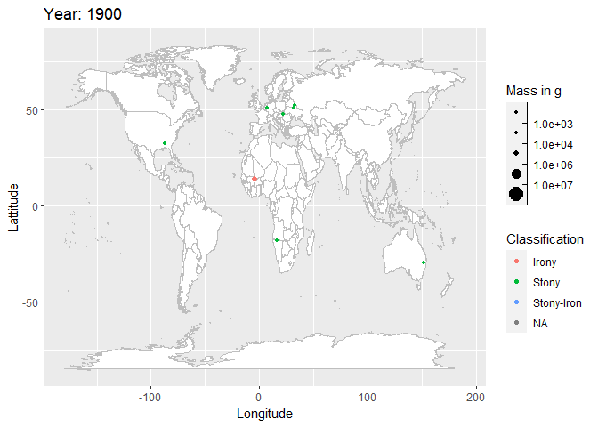

```r
didoufell <- didou %>%
  filter(fall == "Fell") %>%
  filter(year >= 1900)

mapanimated <- worldmap +
  geom_point(data = didoufell, mapping = aes(x = reclong, y = reclat, size = mass, colour = colorclass)) +
  scale_size_binned(breaks = c(1e3, 1e4, 1e6, 1e7)) +
  transition_time(year) +
  labs(title = "Year: {frame_time}") +
  labs(colour = "Classification") +
  labs(size = "Mass in g")+
  shadow_mark(past = T, future=F, alpha=0.3)

animate(mapanimated
        #On peut "allonger" la vidéo en modifiant le paramètres `duration`, qui représente la durée du gif en secondes
        #, duration = 15
        )
```

```r
#Si on préfère avoir une vidéo, mais on peut rencontrer des problèmes avec des solutions différentes en fonction de l'OS ...
#animate(mapanimated, renderer = av_renderer())
```

## Histogrammes de proportions en fonction du statut et du poids des météorites.

On peut faire un histogramme pour évaluer la répartition des météorites en fonction leur statut `fall` et de leur poids `mass`. On écrira une fonction `funhist` pour simplifier le code. Ici, on fera deux histogrammes de proportions, allant de 0g à 10000g.

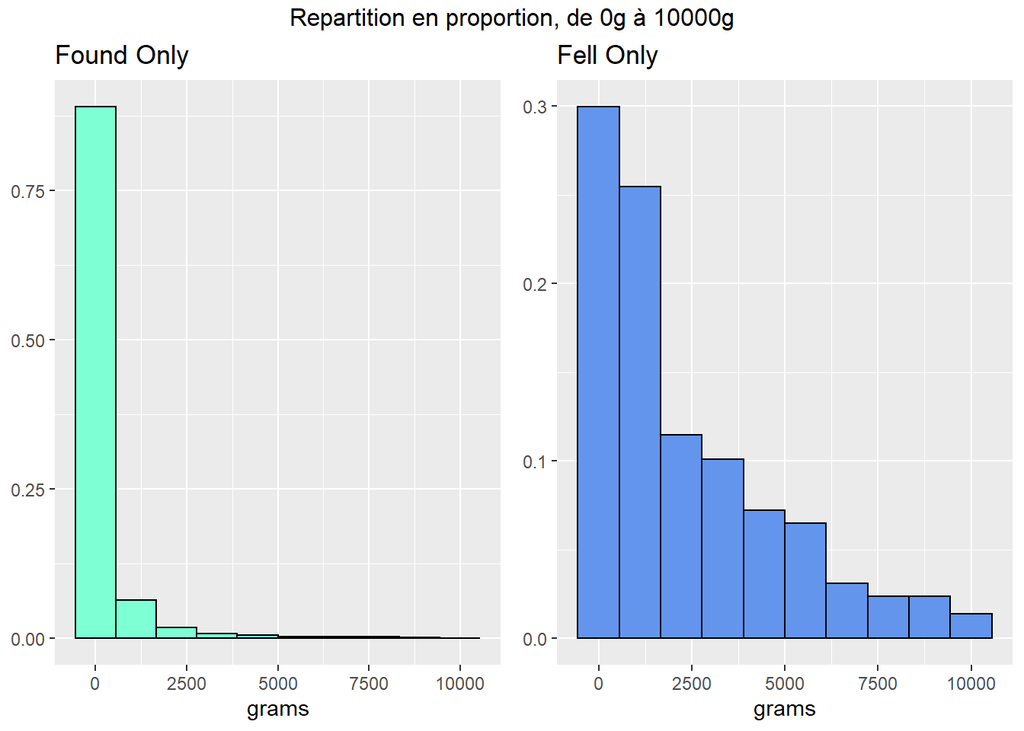

```r
funhist <- function(chr, a, b) {
  ggplot() +
    geom_histogram(data = didou %>% filter(fall == chr) %>% filter(mass >= a) %>% filter(mass <= b),
               mapping = aes(x = mass, y=..count../sum(..count..)),
               bins = 10, fill = ifelse(chr == "Found", "aquamarine1","cornflowerblue"), colour = "black") +
    labs(title = str_c(chr, " Only"),x = "grams", y = NULL)
}

grid.arrange(funhist("Found", 0, 10000), funhist("Fell", 0, 10000), ncol = 2, top = "Repartition en proportion, de 0g à 10000g")
```

On peut se demander si la répartition entre 1000g et 10000g est plus semblable, on va donc faire deux histogrammes en se limitant à ces valeurs.

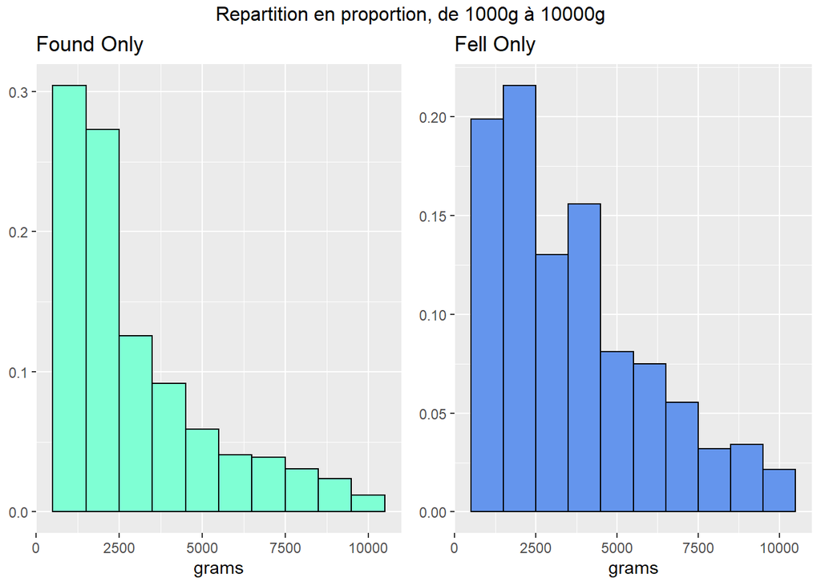

```r
grid.arrange(funhist("Found", 1000, 10000), funhist("Fell", 1000, 10000), ncol = 2, top = "Repartition en proportion, de 1000g à 10000g")
```

## Repartition des météorites en fonction de leur classe et de leur poids.

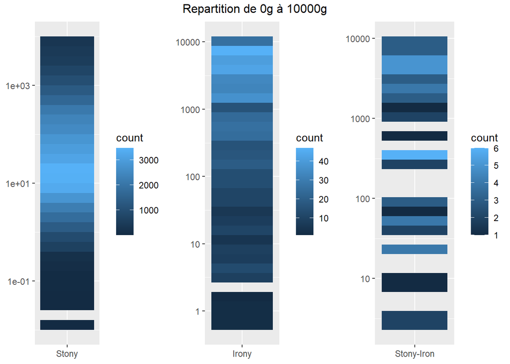

```r
funbin <- function(chr, a, b) {
  ggplot() +
    geom_bin2d(data = didou %>% filter(colorclass == chr) %>% filter(mass >= a) %>% filter(mass <= b),
               mapping = aes(x = colorclass, y = mass)) +
    scale_y_log10() +
    labs(x = NULL, y = NULL)
}

grid.arrange(funbin("Stony", 0, 10000), funbin("Irony", 0, 10000), funbin("Stony-Iron", 0, 10000), ncol = 3, top = "Repartition de 0g à 10000g")
```

## Rvest, affichage d’une photo de la météorite choisie, si disponible sur internet.

```r
DarkMagic <- function(id){
  url <- "http://encyclopedia-of-meteorites.com/"
  php <- "Meteorite?id="
  paste0(url, php, id, collapse = '')

  imgsrc <- read_html(paste0(url, php, id, collapse = '')) %>%
  html_node(xpath = '//*[(((count(preceding-sibling::*) + 1) = 4) and parent::*)]//*[contains(concat( " ", @class, " " ), concat( " ", "img-responsive", " " ))]') %>%
  html_attr('src')

  typ <- tail(str_split(imgsrc,"[.]")[[1]], 1)

  if(is.na(imgsrc)){
    print(str_c("Pas d'images de la météorite ", didou$name[didou$id == id], " (id : ", id, ") dans l'encyclopédie des météorites. (encyclopedia-of-meteorites.com)"))
  }else{
    dwnld <- paste0(url, imgsrc, collapse = '')
    download.file(dwnld,str_c(id,'.',typ), mode = 'wb')

    knitr::include_graphics(str_c(id,'.',typ))
  }
}
```

```r
DarkMagic(42)
```

```
## [1] "Pas d'images de la météorite Acfer 032 (id : 42) dans l'encyclopédie des météorites. (encyclopedia-of-meteorites.com)"
```

```r
DarkMagic(16988)
```

[output not shown]

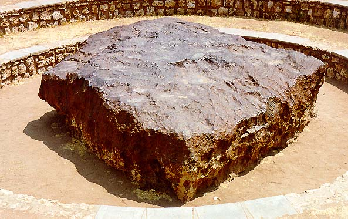

```r
DarkMagic(11890)
```

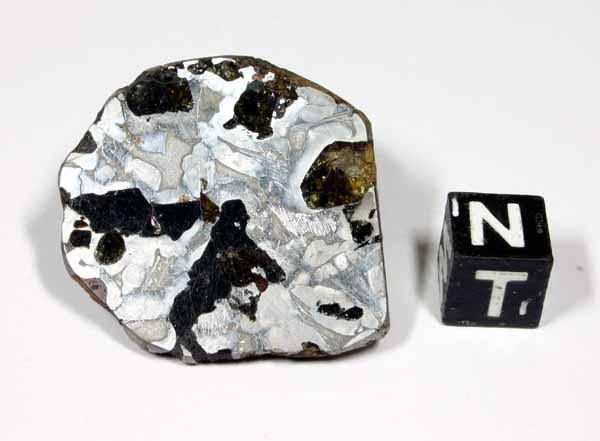

```r
DarkMagic(23510)
```